# Practical 1B - microbiota data

NUTRIM microbiome & metabolome workshop

Author

David Barnett

Published

May 27, 2024

## 1 Intro

Now we’re going to look at the microbiota data.

**A note on sequence data processing**

These data have already been processed into a table, counts of how often each sequence occurs in each sample.

It started as huge fastq text files, full of As, Cs, Ts and Gs, but we will not practice sequence data processing today, because it takes quite a long time to run.

If you generate your data with us at Medical Microbiology, we will run the latest processing approaches on our computational infrastructure and provide you with the processed data.

Nowadays we do amplicon sequencing with Illumina MiSeq, HiSeq, or similar technologies, and denoise the output with DADA2 to produce ASV count tables.

The example data we will use are a little older. The amplicons were sequenced with 454 pyrosequencing and clustered into OTUs, but the core principles of analysis remain the same.

And as you will see later today, the same approaches can also be applied to taxonomic abundance count tables obtained from shotgun metagenomic sequencing.

First we’re going to use the R skills we practised in part A to inspect this data.

**SOLUTION: (read me?)**

- In this practical, solution blocks like this are available…
- But try and write code independently before looking at the answer!
- Attempting to recall knowledge or solve problems is proven to enhance learning.
- So don’t look unless you’re really stuck! 💪

After that, we’ll take a look at some specialist R packages for microbiome analysis.

## 3 Load R packages 📦

```r
library(readxl)
library(here)
library(tidyverse)
```

## 4 Read and inspect data 🔍

Read the metadata file from part 1A, using the RDS version.

```r
meta <- read_rds(file = here("data/papa2012/processed/all_metadata.rds"))
```

Read the count table: this is stored as a TSV (tab-separated variables) formatted text file.

```r
counts <- read_tsv(file = here("data/papa2012/papa2012_OTU_count_table.txt"))
```

```r
counts
```

```
# A tibble: 91 × 36,350
   sample OTU_00001 OTU_00002 OTU_00003 OTU_00004 OTU_00005 OTU_00006 OTU_00007
   <chr>      <dbl>     <dbl>     <dbl>     <dbl>     <dbl>     <dbl>     <dbl>
 1 099_AX         0        56        30         0         0       103         0
 2 199_AX        29         0         9        17         4         5        57
 3 062_BZ         0        95        33         0         0         0        32
 4 194_AZ        75        49       228         0        30        35         0
 5 166_AX       138         3        12         0        13        88       103
 6 219_AX         0       347         2         2         0         0         1
 7 132_AX       121         0         7         0         0         0       181
 8 026_AX         0         0         0         0         0         0         0
 9 102_AZ         0         0         0         0         0         0         0
10 140_AX        47         0        16         1         1        46         4
# ℹ 81 more rows
# ℹ 36,342 more variables: OTU_00008 <dbl>, OTU_00009 <dbl>, OTU_00010 <dbl>,
#   OTU_00011 <dbl>, OTU_00012 <dbl>, OTU_00013 <dbl>, OTU_00014 <dbl>,
#   OTU_00015 <dbl>, OTU_00016 <dbl>, OTU_00017 <dbl>, OTU_00018 <dbl>,
#   OTU_00019 <dbl>, OTU_00020 <dbl>, OTU_00021 <dbl>, OTU_00022 <dbl>,
#   OTU_00023 <dbl>, OTU_00024 <dbl>, OTU_00025 <dbl>, OTU_00026 <dbl>,
#   OTU_00027 <dbl>, OTU_00028 <dbl>, OTU_00029 <dbl>, OTU_00030 <dbl>, …
```

**Your first challenge:** read the taxonomy table stored in `"data/papa2012/papa2012_taxonomy_table.txt"` (call the object `taxonomy`)

**SOLUTION:**

```r
taxonomy <- read_tsv(file = here("data/papa2012/papa2012_taxonomy_table.txt"))
```

```r
taxonomy
```

```
# A tibble: 36,349 × 7
   OTU       Kingdom  Phylum         Class               Order      Family Genus
   <chr>     <chr>    <chr>          <chr>               <chr>      <chr>  <chr>
 1 OTU_00001 Bacteria Firmicutes     Clostridia          Clostridi… Rumin… Faec…
 2 OTU_00002 Bacteria Proteobacteria Gammaproteobacteria Enterobac… Enter… Esch…
 3 OTU_00003 Bacteria Firmicutes     Clostridia          Clostridi… Lachn… Blau…
 4 OTU_00004 Bacteria Firmicutes     Clostridia          Clostridi… Lachn… Rose…
 5 OTU_00005 Bacteria Bacteroidetes  Bacteroidia         Bacteroid… Bacte… Bact…
 6 OTU_00006 Bacteria Firmicutes     Clostridia          Clostridi… Rumin… Faec…
 7 OTU_00007 Bacteria Firmicutes     Clostridia          Clostridi… Lachn… Rose…
 8 OTU_00008 Bacteria Firmicutes     Clostridia          Clostridi… Rumin… Faec…
 9 OTU_00009 Bacteria Proteobacteria Gammaproteobacteria Enterobac… Enter… Esch…
10 OTU_00010 Bacteria Firmicutes     Negativicutes       Selenomon… Veill… Dial…
# ℹ 36,339 more rows
```

### 4.1 Taxonomy table

Now practice inspecting the taxonomy table by completing the following tasks:

**Task 1**

Check how many distinct genera there are. Tip: use `unique()` and `length()`

**SOLUTION:**

```r
taxonomy$Genus %>%
  unique() %>%
  length()
```

```
[1] 142
```

**Task 2**

How many OTUs are there in each Phylum? Tip: use `count()` or `table()`

**SOLUTION:**

```r
taxonomy %>% count(Phylum)
```

```
# A tibble: 9 × 2
  Phylum                        n
  <chr>                     <int>
1 Actinobacteria              307
2 Bacteroidetes             13109
3 Cyanobacteria/Chloroplast     1
4 Firmicutes                17653
5 Fusobacteria                275
6 Proteobacteria             4806
7 Synergistetes                 6
8 Verrucomicrobia              59
9 <NA>                        133
```

```r
taxonomy$Phylum %>% table(useNA = "ifany")
```

```
.
           Actinobacteria             Bacteroidetes Cyanobacteria/Chloroplast
                      307                     13109                         1
               Firmicutes              Fusobacteria            Proteobacteria
                    17653                       275                      4806
            Synergistetes           Verrucomicrobia                      <NA>
                        6                        59                       133
```

**Task 3**

What genera are in the phylum Actinobacteria? Tip: use `filter()`

**SOLUTION:**

```r
taxonomy %>%
  filter(Phylum == "Actinobacteria") %>%
  count(Genus, sort = TRUE)
```

```
# A tibble: 9 × 2
  Genus               n
  <chr>           <int>
1 Bifidobacterium   170
2 Collinsella       111
3 Eggerthella         8
4 Actinomyces         7
5 <NA>                5
6 Gordonibacter       3
7 Asaccharobacter     1
8 Atopobium           1
9 Rothia              1
```

Or for just their names:

```r
taxonomy %>%
  filter(Phylum == "Actinobacteria") %>%
  pull(Genus) %>%
  unique()
```

```
[1] "Collinsella"     "Bifidobacterium" "Eggerthella"     "Atopobium"
[5] "Actinomyces"     NA                "Gordonibacter"   "Asaccharobacter"
[9] "Rothia"
```

### 4.2 OTU count table

First let’s plot a histogram of OTU number 1.

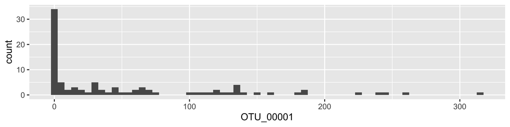

```r
counts %>% ggplot(aes(OTU_00001)) +
  geom_histogram(binwidth = 5)
```

Looks like there are a lot of zeros!

```r
table(OTU00001_has_0_counts = counts$OTU_00001 == 0, useNA = "ifany")
```

```
OTU00001_has_0_counts
FALSE  TRUE
   59    32
```

Attempt the following tasks to explore further!

**Task 1**

Use `filter()` to plot only the non-zero entries for OTU 1.

Try also using `+ scale_x_log10()` to transform the plot axis scale.

**SOLUTION:**

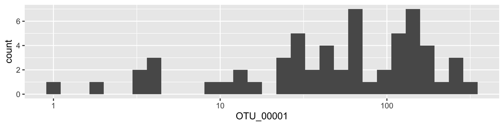

```r
counts %>%
  filter(OTU_00001 != 0) %>%
  ggplot(aes(OTU_00001)) +
  geom_histogram(bins = 30) +
  scale_x_log10()
```

**Task 2**

Use `mutate()` to create a temporary log-transformed variable `log_OTU1` and plot its distribution.

*Note that you can’t do log(0), so you will need to add 1 to all values first, i.e.* `log10(OTU_00001 + 1)`

**SOLUTION:**

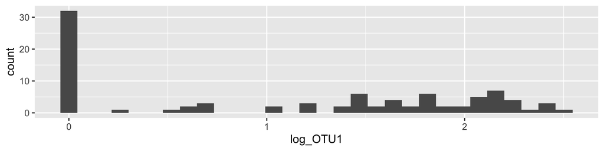

```r
counts %>%
  mutate(log_OTU1 = log10(OTU_00001 + 1)) %>%
  ggplot(aes(log_OTU1)) +
  geom_histogram(bins = 30)
```

**Task 3**

Plot OTU 1 against OTU 2 as a scatter plot using `geom_point`.

Remember to add 1 before log10 transformation of both variables.

**SOLUTION:**

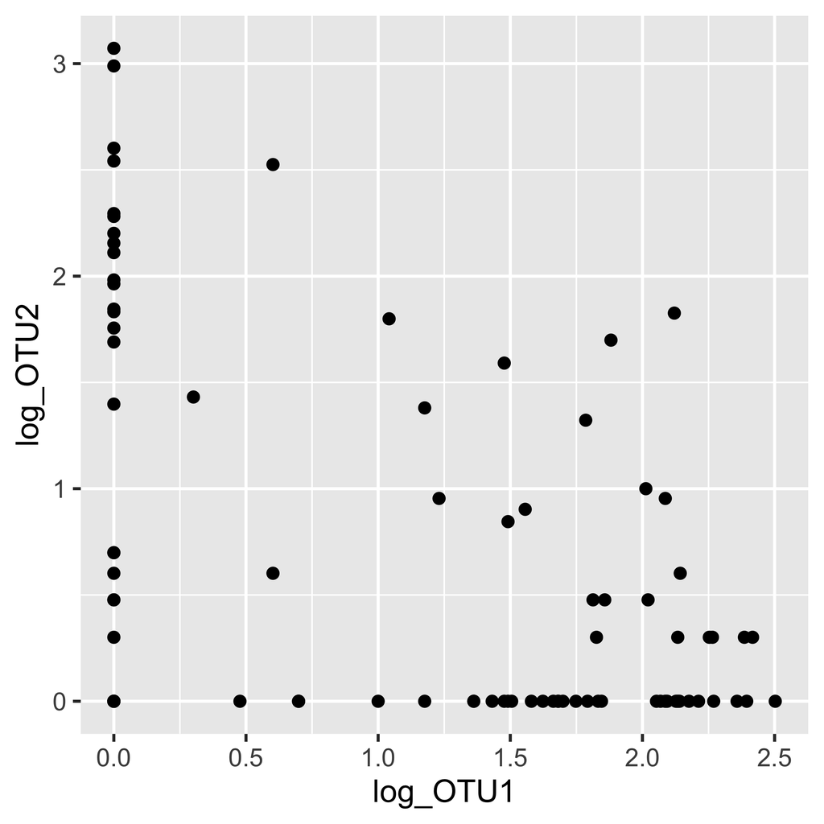

```r
counts %>%
  mutate(log_OTU1 = log10(OTU_00001 + 1)) %>%
  mutate(log_OTU2 = log10(OTU_00002 + 1)) %>%
  ggplot(aes(x = log_OTU1, y = log_OTU2)) +
  geom_point()
```

**Task 4**

But what type of bacteria do these amplicon sequences belong to?

Look up the classifications of OTU 1 and OTU 2 in the taxonomy table.

**SOLUTION:**

```r
taxonomy %>% filter(OTU %in% c("OTU_00001", "OTU_00002"))
```

```
# A tibble: 2 × 7
  OTU       Kingdom  Phylum         Class               Order       Family Genus
  <chr>     <chr>    <chr>          <chr>               <chr>       <chr>  <chr>
1 OTU_00001 Bacteria Firmicutes     Clostridia          Clostridia… Rumin… Faec…
2 OTU_00002 Bacteria Proteobacteria Gammaproteobacteria Enterobact… Enter… Esch…
```

```r
taxonomy %>%
  filter(OTU %in% c("OTU_00001", "OTU_00002")) %>%
  select(OTU, Phylum, Family, Genus)
```

```
# A tibble: 2 × 4
  OTU       Phylum         Family             Genus
  <chr>     <chr>          <chr>              <chr>
1 OTU_00001 Firmicutes     Ruminococcaceae    Faecalibacterium
2 OTU_00002 Proteobacteria Enterobacteriaceae Escherichia/Shigella
```

**Task 5**

Now make histograms and look up the taxonomy for the next thousand OTUs…

**SOLUTION:**

Okay, that was a joke. 🤡

It is possible to make a thousand plots, because R is very good at repetitive tasks.

But, this would not be very useful, because you could not look at them all.

In the next section of this practical, we will explore smarter ways to analyse microbiota compositions.

## 5 Assemble a phyloseq 🛠️

So far we have not used any R packages specialised for microbiome data.

Let’s do so, because it will make our next tasks a lot easier!

```r
library(phyloseq)
library(microViz)
```

```
microViz version 0.12.1 - Copyright (C) 2021-2024 David Barnett
! Website: https://david-barnett.github.io/microViz
✔ Useful?  For citation details, run: `citation("microViz")`
✖ Silence? `suppressPackageStartupMessages(library(microViz))`
```

We will start by combining our three dataframes into one `phyloseq` object

### 5.1 OTU counts + taxonomy

phyloseq uses row or column names to match OTUs across the count and taxonomy tables.

```r
count_matrix <- counts %>% select(-sample) %>% as.matrix()
rownames(count_matrix) <- counts$sample
```

```r
tax_matrix <- as.matrix(taxonomy)
rownames(tax_matrix) <- taxonomy$OTU
```

```r
ps <- phyloseq(
  otu_table(count_matrix, taxa_are_rows = FALSE),
  tax_table(tax_matrix)
)
```

```r
ps
```

```
phyloseq-class experiment-level object
otu_table()   OTU Table:         [ 36349 taxa and 91 samples ]
tax_table()   Taxonomy Table:    [ 36349 taxa by 7 taxonomic ranks ]
```

### 5.2 Adding sample metadata

phyloseq uses row names to match samples (across the OTU count table and the sample metadata).

```r
head(sample_names(ps))
```

```
[1] "099_AX" "199_AX" "062_BZ" "194_AZ" "166_AX" "219_AX"
```

Notice that in the phyloseq object the sample names have underscores, but they have hyphens in the sample metadata.

```r
meta
```

```
# A tibble: 90 × 17
   ID    sample case_control diagnosis activity active   gender ethnicity
   <chr> <chr>  <chr>        <fct>     <fct>    <fct>    <chr>  <chr>
 1 099A  099-AX Case         UC        severe   active   female White
 2 199A  199-AX Control      Other     control  control  female Other
 3 062B  062-BZ Case         CD        mild     active   male   White
 4 194A  194-AZ Case         UC        mild     active   male   White
 5 166A  166-AX Case         UC        severe   active   female Black
 6 219A  219-AX Case         UC        inactive inactive female <NA>
 7 132A  132-AX Case         CD        mild     active   female White
 8 026A  026-AX Case         UC        mild     active   male   White
 9 102A  102-AZ Control      Other     control  control  male   White
10 140A  140-AX Control      Other     control  control  female White
# ℹ 80 more rows
# ℹ 9 more variables: family_history <chr>, age_years <dbl>,
#   immunosuppression_level <fct>, medication <chr>, ibd_fhx <lgl>, abx <lgl>,
#   steroids <lgl>, imsp_other <lgl>, imsp_any <lgl>
```

We can fix that with the `stringr` package `str_replace` function.

```r
meta$sample <- meta$sample %>% str_replace(pattern = "-", replacement = "_")
meta
```

```
# A tibble: 90 × 17
   ID    sample case_control diagnosis activity active   gender ethnicity
   <chr> <chr>  <chr>        <fct>     <fct>    <fct>    <chr>  <chr>
 1 099A  099_AX Case         UC        severe   active   female White
 2 199A  199_AX Control      Other     control  control  female Other
 3 062B  062_BZ Case         CD        mild     active   male   White
 4 194A  194_AZ Case         UC        mild     active   male   White
 5 166A  166_AX Case         UC        severe   active   female Black
 6 219A  219_AX Case         UC        inactive inactive female <NA>
 7 132A  132_AX Case         CD        mild     active   female White
 8 026A  026_AX Case         UC        mild     active   male   White
 9 102A  102_AZ Control      Other     control  control  male   White
10 140A  140_AX Control      Other     control  control  female White
# ℹ 80 more rows
# ℹ 9 more variables: family_history <chr>, age_years <dbl>,
#   immunosuppression_level <fct>, medication <chr>, ibd_fhx <lgl>, abx <lgl>,
#   steroids <lgl>, imsp_other <lgl>, imsp_any <lgl>
```

Now make them row names, check they all match, and add the metadata to the phyloseq object.

```r
meta_df <- as.data.frame(meta)
rownames(meta_df) <- meta$sample
all(rownames(meta_df) %in% sample_names(ps))
```

```
[1] TRUE
```

```r
sample_data(ps) <- meta_df
ps
```

```
phyloseq-class experiment-level object
otu_table()   OTU Table:         [ 36349 taxa and 90 samples ]
sample_data() Sample Data:       [ 90 samples by 17 sample variables ]
tax_table()   Taxonomy Table:    [ 36349 taxa by 7 taxonomic ranks ]
```